# report_Tregubova

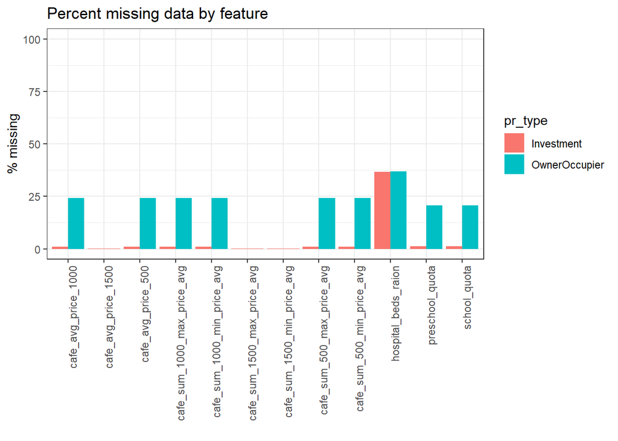

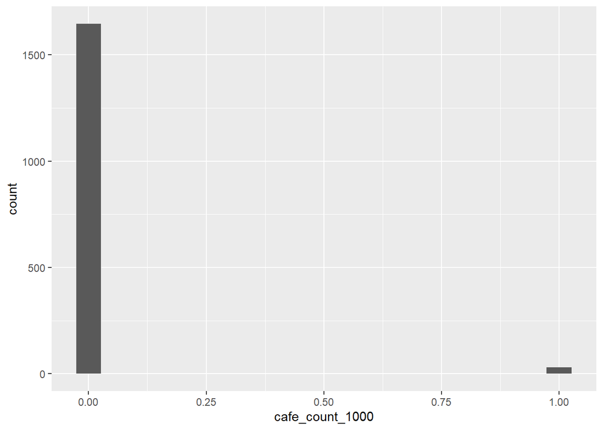

Missings can be replaced with zero because the diagrams below shows that such replacement does not destroy the observing growth of property price with average price in cafes around the property.We do not check all kind of variables suggesting their similarities

```
## No summary function supplied, defaulting to `mean_se()
```

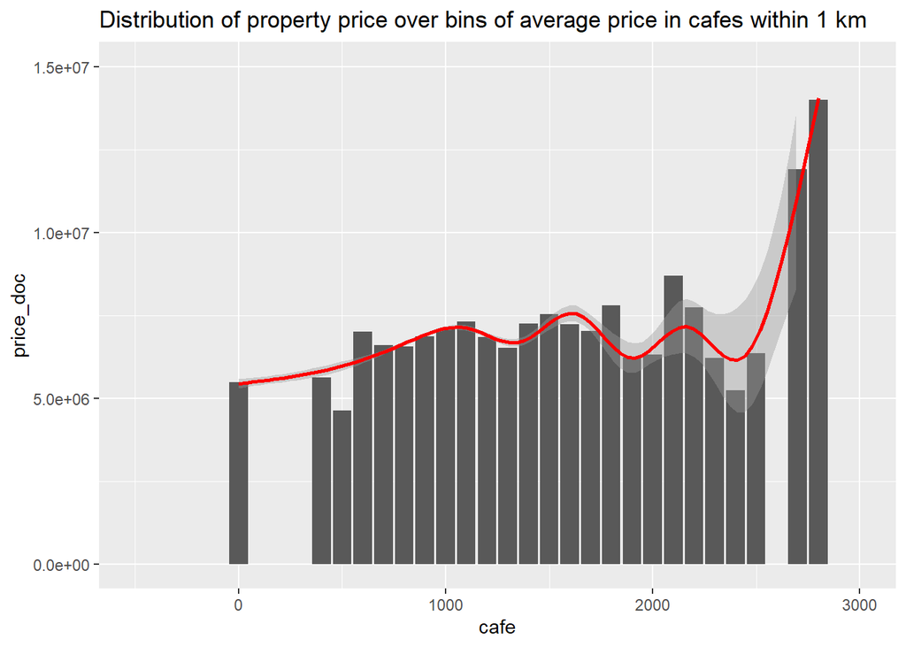

```
## No summary function supplied, defaulting to `mean_se()
```

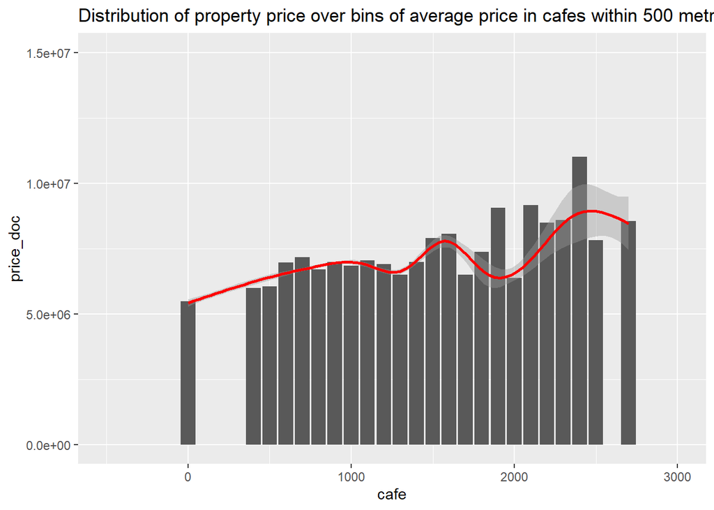

## Bivariate analysis of external variables

Now when we do not have missing values any more, we can analyze the ability of separate variables describing area around the property to explain the price . Starting with those depicting number of facilities within 500 and 1000 metres from apartment we find out low level of correlation between price and any of tested explanatory variables- maximum value is equal to 0.16.Some of the results are worth commenting on.

First, the stongest individual explanatory ability is found out for such factors as number of offices, leisure and sport facilites.

Second, variables green_part and prom_part, which mean share of green area and industrial zone in a region respectively, have negative correlation with price. While we expect negative influence of presence of industrial zone in apartment surroundings, being located not far from parks seems a good indicator, so at first glance, its negative impact on price looks strange. However negative correlation with other variables, evidently associated with urban area give us a clue about suburban and maybe even countryside areas in dataset that do not house a lot of facilities and located faraway from the city centre. We come back to verify this presumption later.

Next point that deserves attention is the fact that among variables which have stronger correlation with price those describing facilities within 500 metres mostly outweight those describing facilities within 1000 metres but it is opposit for weakly correlated features. Possibly, it happens because second group represent less popular public places like mosques or markets.

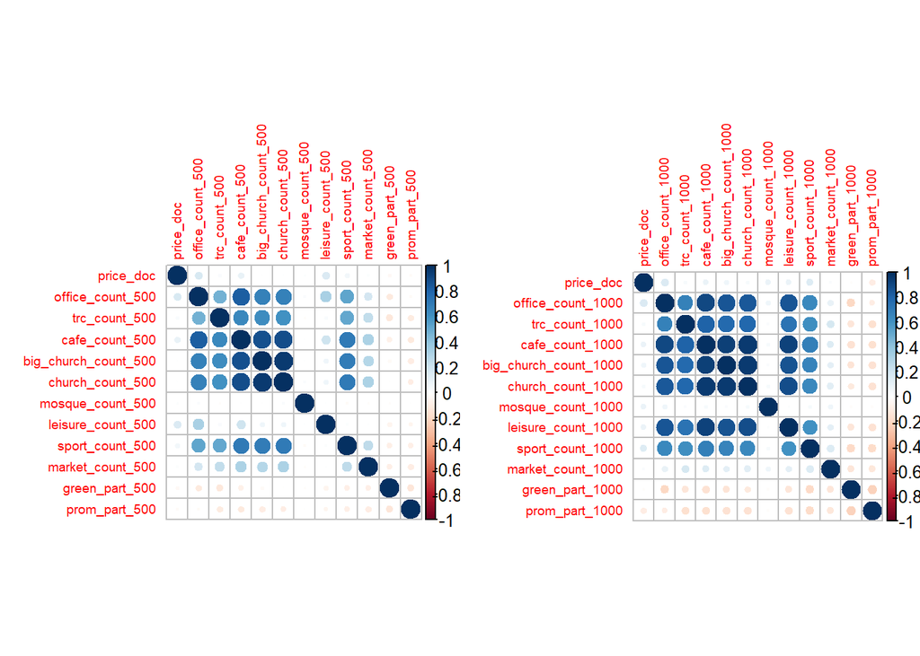

Remarkably, the opossite to the third finding trend can be observed in variables that depict average price in facilites around. The more distance the higher corellation with price. So statistics about facilities within 5km explain price by the best way where average price in cafes are best correlated with apartment price. Possibly, the higher distance better explain the wealth of regions, though that is still small in scale of Moscow and hardly cover any of subareas comppletely.

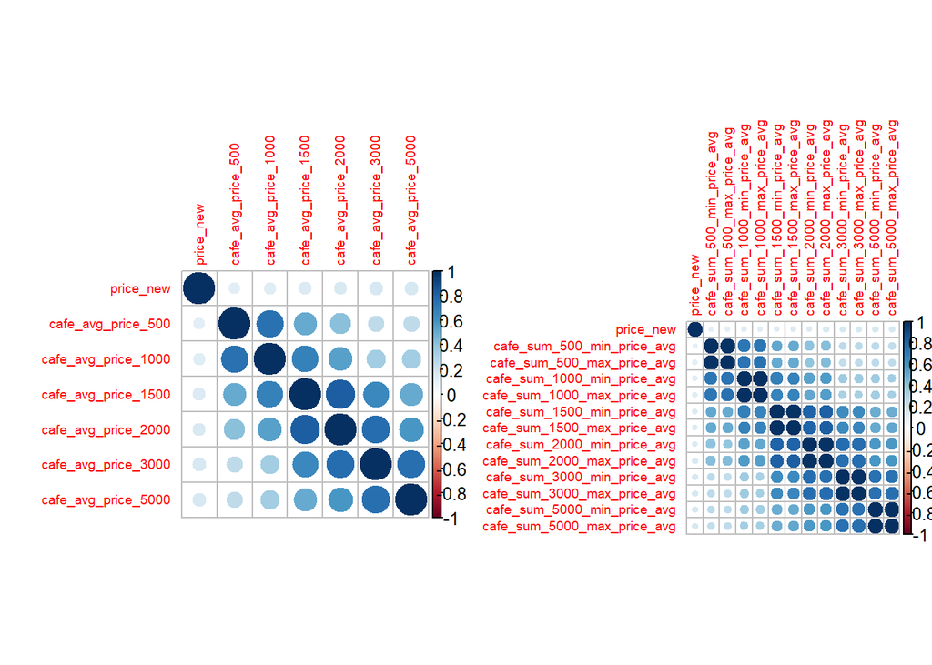

```
##                   price_new cafe_sum_5000_min_price_avg
##                   1.0000000                   0.1773020
##         cafe_avg_price_5000 cafe_sum_5000_max_price_avg
##                   0.1751590                   0.1734185
##         cafe_avg_price_3000 cafe_sum_3000_max_price_avg
##                   0.1712498                   0.1708910
## cafe_sum_3000_min_price_avg cafe_sum_2000_max_price_avg
##                   0.1704653                   0.1638194
##         cafe_avg_price_2000 cafe_sum_2000_min_price_avg
##                   0.1623234                   0.1584112
## cafe_sum_1500_max_price_avg         cafe_avg_price_1500
##                   0.1523007                   0.1521104
## cafe_sum_1500_min_price_avg         cafe_avg_price_1000
##                   0.1507688                   0.1380087
## cafe_sum_1000_max_price_avg cafe_sum_1000_min_price_avg
##                   0.1377564                   0.1376517
##  cafe_sum_500_max_price_avg          cafe_avg_price_500
##                   0.1242488                   0.1228659
##  cafe_sum_500_min_price_avg
##                   0.1198272
```

Turning back to the second suggestion, the visualization of distribution of average price over 10 percentiles of ’part of green area within 1 km variable confirms it. We can observe sharp upward trend in price from 0 to 5 per cent of green cover as well as dramatic decrease of it after green area exceeds 20%. In the middle there are fluctuations that are probably can be explained by other variables.

```
## No summary function supplied, defaulting to `mean_se()
## No summary function supplied, defaulting to `mean_se()
```

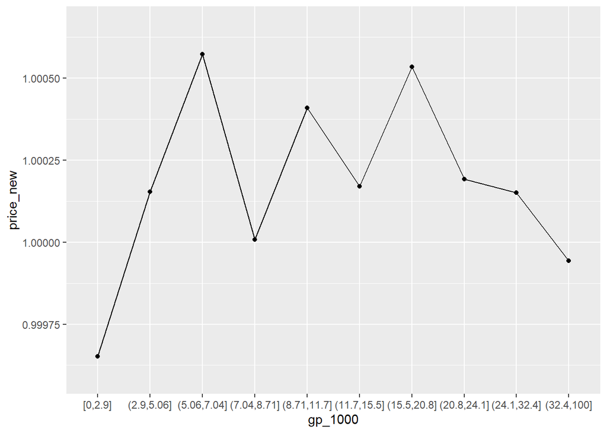

Apart from presence of public spaces, accessability of such services as schools, universities or hospitaks in a district(‘raion’) may make price higher.That is why, the correlation between these variables and price was measured. Interestingly, though we do not how big districts are, variables that describe them in a way ‘yes’/‘no’ have stronger relations with property price than exact number in exact distance. Again sport facilities are higher than others correlated with price. Also, districts housing top Universities are more expencive in terms of cost of accomodation. Among other findings, relationships between number of schools and healthcare centres as well as sport objects. Probably, they are associated with residential areas that well equipped by facilities necessary for families.

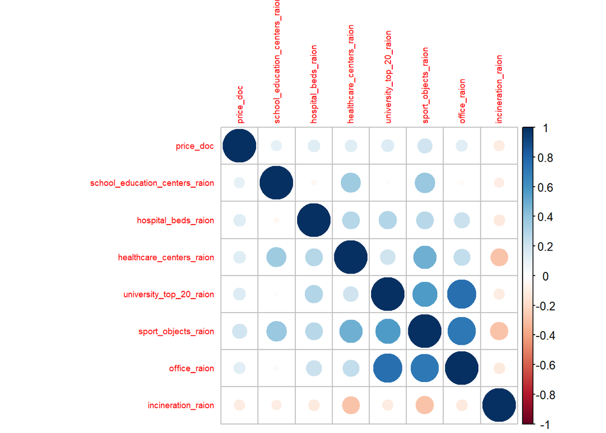

We do not have variable that indicates if a property is located inside the city but a little knowledge of Moscow geography will help us to extract some valuable information about area remotness from given factors. In dataset there are mkad_km and kremlin_km variables that indicate distance of place from ‘mkad’ (Moscow Circle Auto Road) that is practically a border between the city of Moscow and its suburbs- and from kremlin - the residence of the president that is considered the centre of Moscow.

The diagram below shows that price of accomodation gradually decrease with the distance from Kremlin, aka Moscow centre.

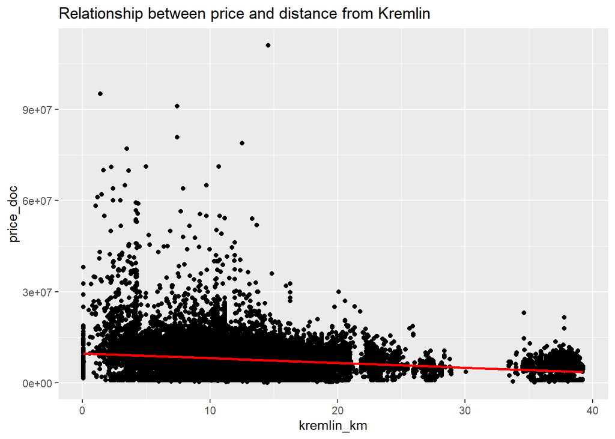

Although the distance from the Circle Road does not indicate if an apartment is in or out of it, kremlin_km feature allows us to roughly calculate it. Once we know the average distance from kremlin to accomodations close to mkad, that technicaly is a radius of the circle, we will be able to differ inside and outside locations, simply by comparing this measure with the remotness of a property from kremlin.

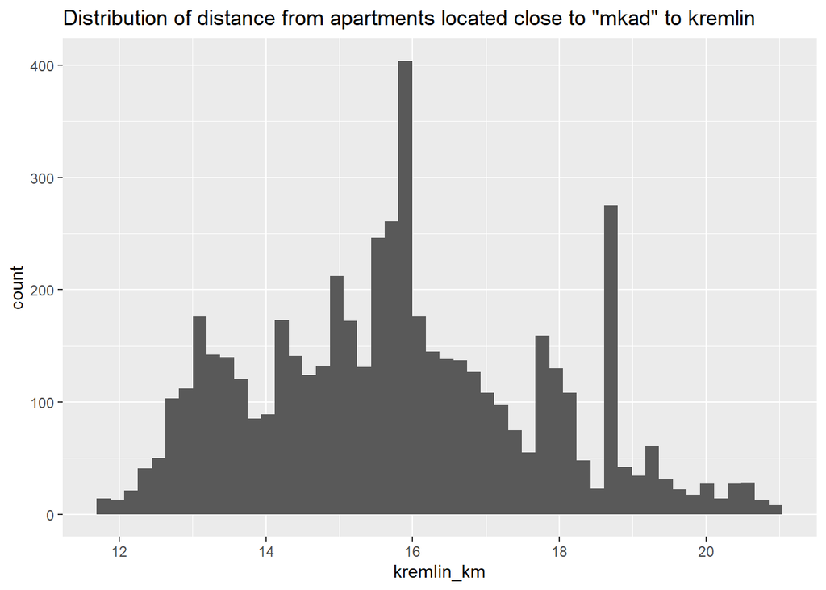

```
## [1] 15.74657
```

```
## [1] 15.85188
```

According to t-test there is a statistical significant difference in prices inside and outside the circle road

```
##
##  Welch Two Sample t-test
##
## data:  log(unlist(data_region %>% filter(is_urban == 1) %>% select(price_new))) and log(unlist(data_region %>% filter(is_urban == 0) %>% select(price_new)))
## t = 31.331, df = 25305, p-value < 2.2e-16
## alternative hypothesis: true difference in means is not equal to 0
## 95 percent confidence interval:
##  0.001175358 0.001332235
## sample estimates:
##     mean of x     mean of y
##  0.0005849291 -0.0006688672
```

However diagrams almost does not demonsrate big difference between two types of location.

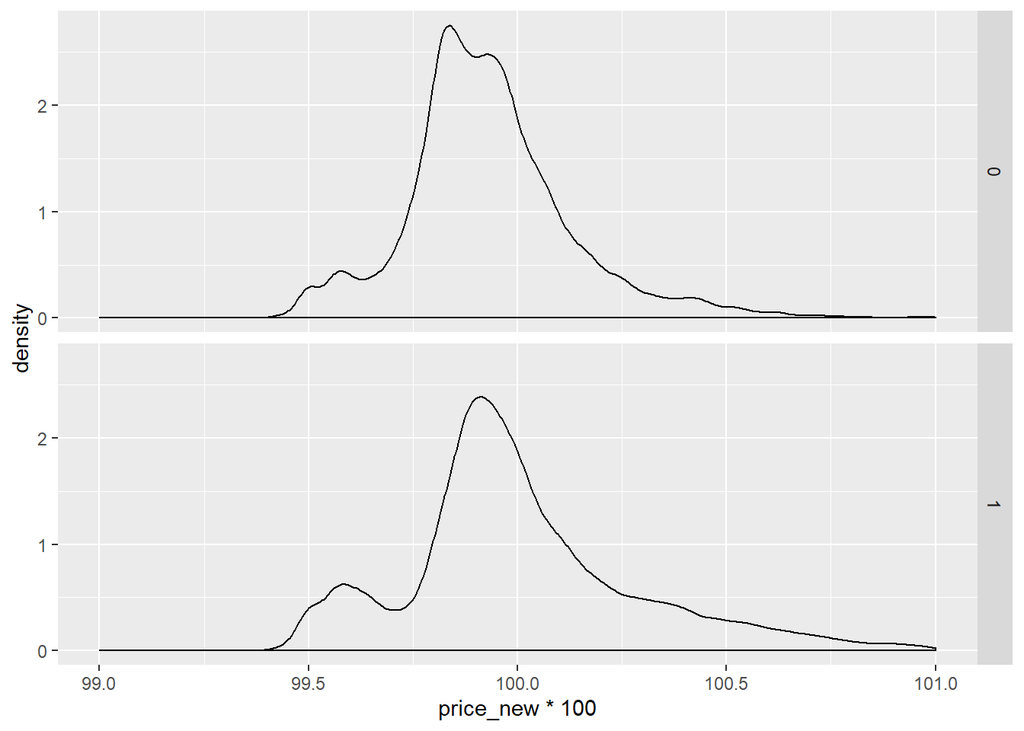

Along with closeness to centre, the distance from public transpot should be important, especially for those who live in Moscow suburbs. At the same time, despite correlation matrix supports negative association between property price and distance to a transport station, the strength of correlation was expected to be bigger.The highest correlation are between property price in suburb and its distance to railway(‘zd_vokzaly_avto_km’) and bus stations.It is expained by daily need to use this transport for commuting - dataset has no separate information about commuter train stations, so we may assume it is added to the first variable). Unexpectedly, metro proximity does not have a lot of impact on price,even iside the city, maybe because of the fact that now it is equally spread over all Moscow area, so other rare factors contribute better. Last, we can see high correlation between variables of distance from metro, railway and bus station. It means that in the city they are often located close to each other, creating transport hubs.

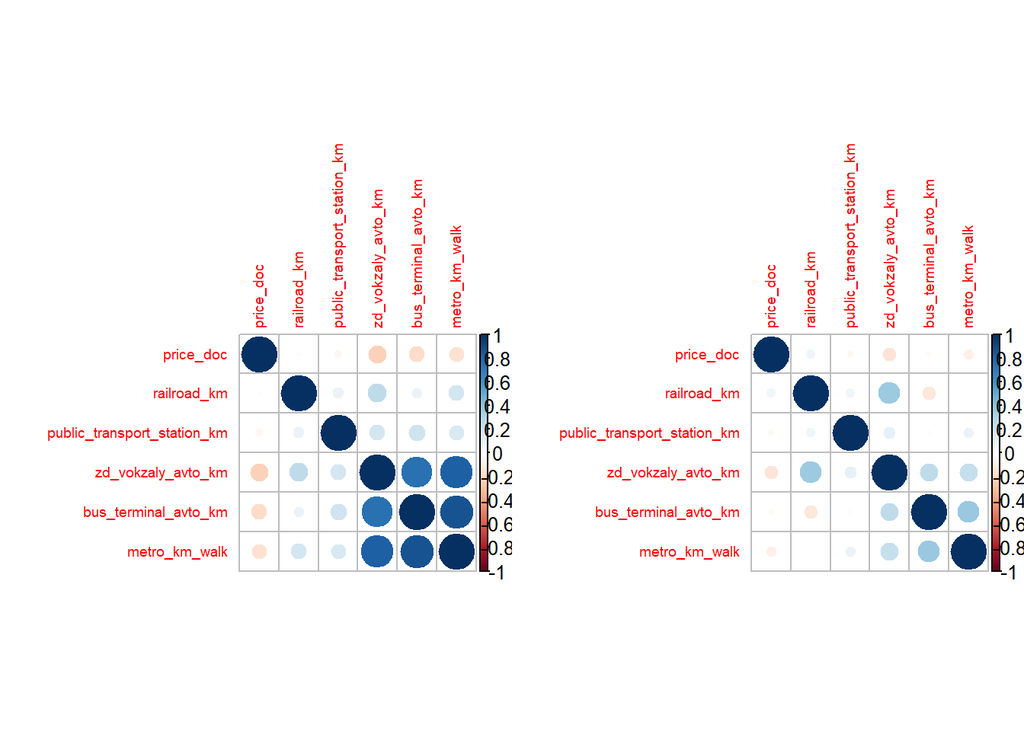

# Linear regression modeling

Once we have analyzed all variables, it is time to merge two datasets together and build linear regression

```
## 'data.frame':    25309 obs. of  38 variables:
##  $ id                            : int  1 2 3 4 5 6 7 8 9 10 ...
##  $ full_sq                       : num  43 34 43 89 77 67 25 44 42 36 ...
##  $ life_squ                      : num  27 19 29 50 77 46 14 44 27 21 ...
##  $ floor                         : int  4 3 2 9 4 14 10 5 5 9 ...
##  $ material                      : Factor w/ 6 levels "1","2","3","4",..: 1 1 1 1 1 1 1 1 1 1 ...
##  $ num_room                      : int  2 1 2 3 3 2 1 2 2 1 ...
##  $ kitch_sq                      : num  6 6 6 6 6 6 6 6 6 6 ...
##  $ state                         : Ord.factor w/ 5 levels "0"<"1"<"2"<"3"<..: 1 1 1 1 1 1 1 1 1 1 ...
##  $ price_new                     : num  1 1 1 1.01 1.01 ...
##  $ product_type                  : Factor w/ 2 levels "Investment","OwnerOccupier": 1 1 1 1 1 1 1 1 1 1 ...
##  $ cafe_avg_price_500            : Factor w/ 1161 levels "2011-08-20","2011-08-23",..: 1 2 3 4 5 6 7 8 9 10 ...
##  $ sport_objects_raion           : int  9576 6880 5879 13087 5706 2418 2459 9576 6507 9347 ...
##  $ cafe_sum_1500_max_price_avg   : int  5 8 7 10 9 3 5 5 6 8 ...
##  $ sport_count_1000              : Factor w/ 2 levels "no","yes": 1 2 1 1 1 1 1 1 1 1 ...
```

[output cut: 24 more lines]

Some numeric factors mistakenly were recognised as factors by program, so before running model, they should be transformed to numeric

Adding all new variables to the first model improves R-squared on 7%. However several variables such as num_room,university_top_20_raion, metro_km_walk have changed the sign because of multicolleniarity that is counterintuitive, so we should solve this problem.

```
##
## Call:
## lm(formula = price_new ~ ., data = data[-1])
##
## Residuals:
##       Min        1Q    Median        3Q       Max
## -0.014109 -0.000834  0.000268  0.001059  0.075402
##
## Coefficients: (1 not defined because of singularities)
##                                  Estimate Std. Error  t value Pr(>|t|)
## (Intercept)                     9.941e-01  2.298e-04 4326.070  < 2e-16 ***
## full_sq                         1.271e-04  2.135e-06   59.531  < 2e-16 ***
## life_squ                        1.349e-05  1.958e-06    6.889 5.73e-12 ***
## floor                           2.916e-05  3.481e-06    8.378  < 2e-16 ***
## material2                       1.803e-04  6.172e-05    2.920 0.003499 **
## material4                       8.580e-04  9.441e-05    9.088  < 2e-16 ***
## material5                      -1.386e-04  7.596e-05   -1.824 0.068112 .
## material6                       6.247e-05  1.302e-04    0.480 0.631334
## num_room                       -5.258e-04  4.313e-05  -12.191  < 2e-16 ***
## kitch_sq                        2.562e-05  5.418e-06    4.728 2.27e-06 ***
## state.L                         1.365e-03  9.706e-05   14.064  < 2e-16 ***
## state.Q                         1.337e-03  8.026e-05   16.659  < 2e-16 ***
## state.C                         3.670e-04  6.428e-05    5.710 1.14e-08 ***
## state^4                         1.492e-04  4.750e-05    3.141 0.001687 **
## product_typeOwnerOccupier       7.102e-04  6.801e-05   10.444  < 2e-16 ***
## cafe_avg_price_500             -1.851e-07  9.049e-08   -2.045 0.040829 *
## sport_objects_raion             7.908e-08  3.152e-08    2.509 0.012109 *
## cafe_sum_1500_max_price_avg     4.202e-05  2.019e-05    2.081 0.037423 *
## sport_count_1000                4.533e-04  9.430e-05    4.807 1.54e-06 ***
## school_education_centers_raion         NA         NA       NA       NA
## cafe_avg_price_1500            -3.125e-06  4.691e-07   -6.662 2.77e-11 ***
## hospital_beds_raion             4.395e-09  1.273e-09    3.453 0.000555 ***
## healthcare_centers_raion       -4.812e-04  1.606e-04   -2.997 0.002731 **
## university_top_20_raion        -2.284e-03  1.941e-04  -11.769  < 2e-16 ***
## cafe_sum_500_max_price_avg     -2.086e-07  2.849e-08   -7.322 2.52e-13 ***
## cafe_sum_1000_min_price_avg     1.488e-05  2.600e-05    0.572 0.567274
## cafe_sum_1000_max_price_avg    -7.404e-08  3.039e-08   -2.436 0.014845 *
## office_raion                    1.038e-07  1.659e-08    6.258 3.97e-10 ***
## incineration_raion             -5.953e-06  6.019e-05   -0.099 0.921224
## cafe_sum_2000_max_price_avg     1.959e-07  2.042e-08    9.592  < 2e-16 ***
## cafe_sum_3000_min_price_avg     2.240e-05  1.539e-05    1.455 0.145658
## cafe_sum_3000_max_price_avg     6.450e-05  5.729e-05    1.126 0.260271
## cafe_sum_5000_min_price_avg    -1.678e-05  5.004e-06   -3.353 0.000801 ***
## cafe_sum_5000_max_price_avg    -1.321e-04  7.511e-06  -17.590  < 2e-16 ***
## kremlin_km                      4.079e-05  1.231e-05    3.314 0.000922 ***
## mkad_km                         6.527e-05  8.133e-06    8.026 1.05e-15 ***
## is_urban1                       2.767e-04  7.144e-05    3.873 0.000108 ***
## railroad_km                     4.500e-05  1.359e-05    3.312 0.000929 ***
## public_transport_station_km    -4.003e-04  1.479e-04   -2.707 0.006804 **
## zd_vokzaly_avto_km             -1.177e-04  8.622e-06  -13.657  < 2e-16 ***
## bus_terminal_avto_km           -4.254e-06  4.857e-06   -0.876 0.381169
## metro_km_walk                  -3.340e-05  1.262e-05   -2.647 0.008122 **
## green_part_1000                 3.641e-06  1.675e-06    2.174 0.029720 *
## ---
## Signif. codes:  0 '***' 0.001 '**' 0.01 '*' 0.05 '.' 0.1 ' ' 1
##
## Residual standard error: 0.00269 on 25267 degrees of freedom
## Multiple R-squared:  0.4974, Adjusted R-squared:  0.4966
## F-statistic:   610 on 41 and 25267 DF,  p-value: < 2.2e-16
```

For this purpose we will steadly exclude values that are highly correlated with those which better than them explain variation of dependable variable.

We start with variables that describe property. We can see that life_sq and num_room have high correlation with full_sq. So we remove them from model and try linear regression again

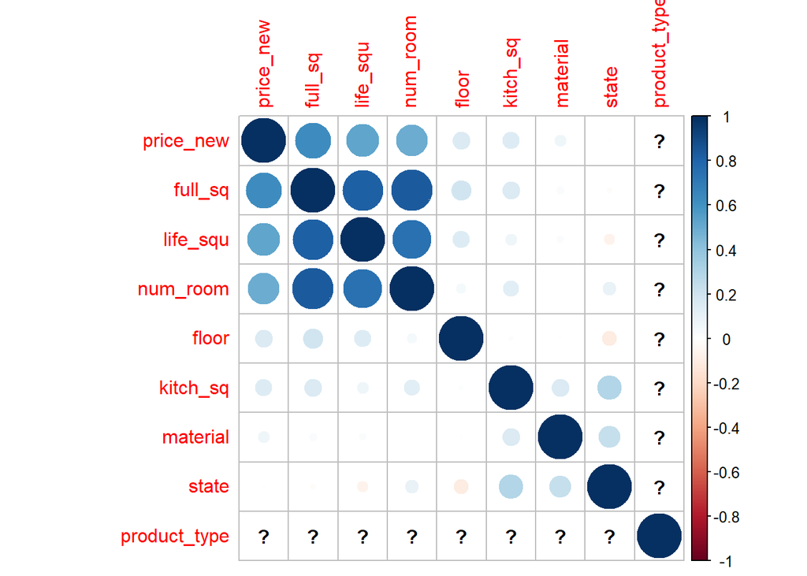

```
##
## Call:
## lm(formula = data$price_new ~ ., data = data[, -which(colnames(data) %in%
##     c(drop_vars, "price_new"))])
##
## Residuals:
##       Min        1Q    Median        3Q       Max
## -0.013788 -0.000855  0.000267  0.001068  0.075280
##
## Coefficients:
##                               Estimate Std. Error  t value Pr(>|t|)
## (Intercept)                  9.944e-01  2.392e-04 4157.573  < 2e-16 ***
## id                           3.841e-08  1.012e-08    3.795 0.000148 ***
## full_sq                      1.149e-04  9.754e-07  117.818  < 2e-16 ***
## floor                        3.324e-05  3.464e-06    9.595  < 2e-16 ***
## material2                    1.736e-04  6.191e-05    2.804 0.005045 **
## material4                    1.020e-03  9.383e-05   10.866  < 2e-16 ***
## material5                   -1.553e-04  7.617e-05   -2.039 0.041448 *
## material6                    1.804e-04  1.302e-04    1.386 0.165751
## kitch_sq                     3.603e-05  5.375e-06    6.703 2.08e-11 ***
## state.L                      1.353e-03  9.772e-05   13.850  < 2e-16 ***
## state.Q                      1.364e-03  8.040e-05   16.964  < 2e-16 ***
## state.C                      4.537e-04  6.403e-05    7.086 1.41e-12 ***
## state^4                      9.037e-05  4.742e-05    1.906 0.056664 .
## product_typeOwnerOccupier    9.240e-04  6.724e-05   13.741  < 2e-16 ***
## cafe_avg_price_500          -1.425e-06  3.258e-07   -4.372 1.23e-05 ***
## sport_objects_raion          1.017e-07  3.155e-08    3.223 0.001272 **
## cafe_sum_1500_max_price_avg  3.471e-05  2.024e-05    1.715 0.086414 .
## sport_count_1000             4.191e-04  9.456e-05    4.432 9.38e-06 ***
## cafe_avg_price_1500         -3.112e-06  4.704e-07   -6.615 3.78e-11 ***
## hospital_beds_raion          3.802e-09  1.273e-09    2.986 0.002828 **
## healthcare_centers_raion    -4.745e-04  1.610e-04   -2.946 0.003219 **
## university_top_20_raion     -2.301e-03  1.946e-04  -11.823  < 2e-16 ***
## cafe_sum_500_max_price_avg  -2.003e-07  2.857e-08   -7.009 2.46e-12 ***
## cafe_sum_1000_min_price_avg  1.921e-05  2.608e-05    0.737 0.461264
## cafe_sum_1000_max_price_avg -9.086e-08  3.045e-08   -2.984 0.002848 **
## office_raion                 1.025e-07  1.665e-08    6.156 7.55e-10 ***
## incineration_raion           1.130e-06  6.038e-05    0.019 0.985075
## cafe_sum_2000_max_price_avg  1.935e-07  2.048e-08    9.448  < 2e-16 ***
## cafe_sum_3000_min_price_avg  2.916e-05  1.543e-05    1.890 0.058715 .
## cafe_sum_3000_max_price_avg  7.299e-05  5.748e-05    1.270 0.204157
## cafe_sum_5000_min_price_avg -1.404e-05  5.014e-06   -2.800 0.005116 **
## cafe_sum_5000_max_price_avg -1.351e-04  7.530e-06  -17.942  < 2e-16 ***
## kremlin_km                   3.766e-05  1.234e-05    3.053 0.002269 **
## mkad_km                      6.366e-05  8.154e-06    7.808 6.02e-15 ***
## is_urban1                    2.771e-04  7.166e-05    3.867 0.000110 ***
## railroad_km                  5.066e-05  1.362e-05    3.719 0.000201 ***
## public_transport_station_km -4.422e-04  1.487e-04   -2.974 0.002938 **
## zd_vokzaly_avto_km          -1.172e-04  8.644e-06  -13.554  < 2e-16 ***
## bus_terminal_avto_km        -3.292e-06  4.871e-06   -0.676 0.499137
## metro_km_walk               -2.998e-05  1.265e-05   -2.370 0.017783 *
## green_part_1000              3.804e-06  1.680e-06    2.265 0.023529 *
## ---
## Signif. codes:  0 '***' 0.001 '**' 0.01 '*' 0.05 '.' 0.1 ' ' 1
##
## Residual standard error: 0.002698 on 25268 degrees of freedom
## Multiple R-squared:  0.4945, Adjusted R-squared:  0.4937
## F-statistic: 617.9 on 40 and 25268 DF,  p-value: < 2.2e-16
```

Next, the correlation of variables describing location is being performed. Ordering from high to low correlation with dependable variablehallow us to select highly correlated with price and not associated with each other variables by choosing only those in matrix that contain high coefficients values only to the right side of the main diagonal

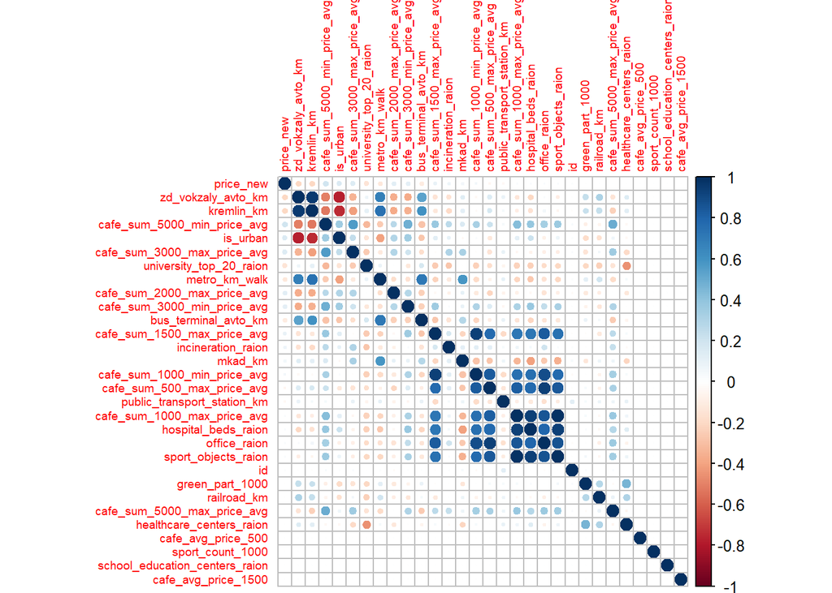

```
##
## Call:
## lm(formula = data$price_new ~ ., data = data[, -which(colnames(data) %in%
##     c(drop_vars, "price_new", "id"))])
##
## Residuals:
##       Min        1Q    Median        3Q       Max
## -0.013723 -0.000873  0.000257  0.001072  0.075415
##
## Coefficients:
##                               Estimate Std. Error  t value Pr(>|t|)
## (Intercept)                  9.937e-01  1.647e-04 6032.823  < 2e-16 ***
## full_sq                      1.167e-04  9.881e-07  118.064  < 2e-16 ***
## floor                        3.383e-05  3.515e-06    9.625  < 2e-16 ***
## material2                    2.515e-04  6.216e-05    4.047 5.21e-05 ***
## material4                    1.133e-03  9.471e-05   11.960  < 2e-16 ***
## material5                   -1.241e-04  7.711e-05   -1.610 0.107400
## material6                    2.830e-04  1.318e-04    2.148 0.031744 *
## kitch_sq                     3.771e-05  5.449e-06    6.920 4.61e-12 ***
## state.L                      1.205e-03  9.459e-05   12.745  < 2e-16 ***
## state.Q                      1.432e-03  7.914e-05   18.092  < 2e-16 ***
## state.C                      4.608e-04  6.468e-05    7.124 1.08e-12 ***
## state^4                      6.631e-05  4.793e-05    1.384 0.166483
## product_typeOwnerOccupier    5.962e-04  6.334e-05    9.413  < 2e-16 ***
## sport_count_1000             5.897e-04  8.876e-05    6.644 3.12e-11 ***
## cafe_avg_price_1500         -4.130e-06  4.727e-07   -8.736  < 2e-16 ***
## hospital_beds_raion          1.783e-09  7.865e-10    2.267 0.023414 *
## healthcare_centers_raion     5.504e-04  1.433e-04    3.841 0.000123 ***
## office_raion                 5.078e-08  8.258e-09    6.149 7.91e-10 ***
## cafe_sum_2000_max_price_avg  2.535e-07  2.001e-08   12.665  < 2e-16 ***
## cafe_sum_3000_min_price_avg  1.322e-05  1.446e-05    0.914 0.360812
## cafe_sum_3000_max_price_avg  2.206e-05  5.251e-05    0.420 0.674436
## cafe_sum_5000_min_price_avg -3.394e-05  4.820e-06   -7.042 1.95e-12 ***
## mkad_km                      4.497e-05  7.522e-06    5.978 2.29e-09 ***
## is_urban1                    3.055e-04  6.644e-05    4.599 4.28e-06 ***
## railroad_km                  4.283e-05  1.310e-05    3.271 0.001074 **
## public_transport_station_km -8.177e-04  1.475e-04   -5.546 2.96e-08 ***
## zd_vokzaly_avto_km          -1.054e-04  5.647e-06  -18.672  < 2e-16 ***
## bus_terminal_avto_km         4.571e-06  4.497e-06    1.016 0.309427
## metro_km_walk                1.255e-06  1.031e-05    0.122 0.903178
## green_part_1000              4.289e-06  1.689e-06    2.540 0.011100 *
## ---
## Signif. codes:  0 '***' 0.001 '**' 0.01 '*' 0.05 '.' 0.1 ' ' 1
##
## Residual standard error: 0.002741 on 25279 degrees of freedom
## Multiple R-squared:  0.4779, Adjusted R-squared:  0.4773
## F-statistic: 797.9 on 29 and 25279 DF,  p-value: < 2.2e-16
```

```
##                                 GVIF Df GVIF^(1/(2*Df))
## full_sq                     1.204557  1        1.097523
## floor                       1.172922  1        1.083015
## material                    1.664555  4        1.065767
## kitch_sq                    1.399721  1        1.183098
## state                       2.217652  4        1.104680
## product_type                2.485172  1        1.576443
## sport_count_1000            1.867697  1        1.366637
## cafe_avg_price_1500         1.291511  1        1.136446
## hospital_beds_raion         5.376571  1        2.318743
## healthcare_centers_raion    1.773026  1        1.331550
## office_raion                4.872755  1        2.207432
## cafe_sum_2000_max_price_avg 1.398965  1        1.182779
## cafe_sum_3000_min_price_avg 1.588859  1        1.260500
## cafe_sum_3000_max_price_avg 2.158633  1        1.469229
## cafe_sum_5000_min_price_avg 3.305930  1        1.818222
## mkad_km                     3.680048  1        1.918345
## is_urban                    3.276712  1        1.810169
## railroad_km                 1.436731  1        1.198637
## public_transport_station_km 1.158342  1        1.076263
## zd_vokzaly_avto_km          7.901917  1        2.811035
## bus_terminal_avto_km        2.611833  1        1.616117
## metro_km_walk               6.480707  1        2.545723
## green_part_1000             1.408661  1        1.186870
```

Along with ‘zd_vokzaly_avto_km’ we decrease number of levels in factor ‘material’. Also we notice weak explanatory ability of kitchen area, that is why, new variable ‘part_kitchen’ that means part of property that takes kitchen was created in attempt to strengthen model

```
##
## Call:
## lm(formula = data$price_new ~ ., data = data[, -which(colnames(data) %in%
##     c(dro_vars, "price_new", "id"))])
##
## Residuals:
##       Min        1Q    Median        3Q       Max
## -0.013483 -0.000903  0.000235  0.001093  0.075515
##
## Coefficients:
##                               Estimate Std. Error  t value Pr(>|t|)
## (Intercept)                  9.916e-01  1.440e-04 6884.189  < 2e-16 ***
## full_sq                      1.244e-04  1.034e-06  120.252  < 2e-16 ***
## floor                        2.697e-05  3.488e-06    7.733 1.09e-14 ***
## state.L                      1.184e-03  9.408e-05   12.588  < 2e-16 ***
## state.Q                      1.403e-03  7.912e-05   17.728  < 2e-16 ***
## state.C                      5.109e-04  6.439e-05    7.933 2.22e-15 ***
## state^4                      6.318e-05  4.756e-05    1.328  0.18405
## product_typeOwnerOccupier    4.540e-04  6.094e-05    7.449 9.69e-14 ***
## sport_count_1000             7.145e-04  8.873e-05    8.053 8.45e-16 ***
## cafe_avg_price_1500         -4.941e-06  4.719e-07  -10.469  < 2e-16 ***
## healthcare_centers_raion     2.589e-04  1.396e-04    1.854  0.06374 .
## office_raion                 2.669e-08  5.087e-09    5.248 1.55e-07 ***
## cafe_sum_2000_max_price_avg  2.740e-07  2.005e-08   13.663  < 2e-16 ***
## cafe_sum_3000_min_price_avg  3.691e-05  1.421e-05    2.597  0.00941 **
## cafe_sum_3000_max_price_avg  1.796e-05  5.255e-05    0.342  0.73260
## cafe_sum_5000_min_price_avg -3.604e-07  4.529e-06   -0.080  0.93657
## mkad_km                      5.371e-05  6.993e-06    7.681 1.64e-14 ***
## is_urban1                    1.134e-03  5.062e-05   22.396  < 2e-16 ***
## railroad_km                 -3.071e-05  1.238e-05   -2.480  0.01315 *
## public_transport_station_km -1.134e-03  1.459e-04   -7.772 8.05e-15 ***
## bus_terminal_avto_km        -7.114e-06  4.478e-06   -1.589  0.11218
## metro_km_walk               -8.553e-05  9.037e-06   -9.464  < 2e-16 ***
## green_part_1000              4.702e-06  1.689e-06    2.784  0.00538 **
## is_material41                1.146e-03  9.390e-05   12.210  < 2e-16 ***
## part_kitchen                 3.570e-03  2.495e-04   14.306  < 2e-16 ***
## ---
## Signif. codes:  0 '***' 0.001 '**' 0.01 '*' 0.05 '.' 0.1 ' ' 1
##
## Residual standard error: 0.002755 on 25284 degrees of freedom
## Multiple R-squared:  0.4727, Adjusted R-squared:  0.4722
## F-statistic: 944.3 on 24 and 25284 DF,  p-value: < 2.2e-16
```

‘Part kitchen’ indeed happened to be significant. Now, all variables have explicable direction of relationship with price. Warnings are possible about ‘cafe_avg_price_1500’ that have a negative sign but we can make assumption that low average price means prevailing number of fast food restaurants around that usually imply shopping malls, cinema etc that, ultimetly positevly influence living conditions, thus increasing price.

After building model we continue to check if standard linear model assumptions are justified.

For theoretical regression erros are assumed to be normally distributed but in our case QQ-plot shows that standardized residuals do not follow normal distribution because points do not properly match the line and histogram is a bit skewed.

```
##
## Call:
## lm(formula = data$price_new ~ ., data = data[, -which(colnames(data) %in%
##     c(dro_vars, "price_new", "id"))])
##
## Residuals:
##       Min        1Q    Median        3Q       Max
## -0.013483 -0.000903  0.000235  0.001093  0.075515
##
## Coefficients:
##                               Estimate Std. Error  t value Pr(>|t|)
## (Intercept)                  9.916e-01  1.440e-04 6884.189  < 2e-16 ***
## full_sq                      1.244e-04  1.034e-06  120.252  < 2e-16 ***
## floor                        2.697e-05  3.488e-06    7.733 1.09e-14 ***
## state.L                      1.184e-03  9.408e-05   12.588  < 2e-16 ***
## state.Q                      1.403e-03  7.912e-05   17.728  < 2e-16 ***
## state.C                      5.109e-04  6.439e-05    7.933 2.22e-15 ***
## state^4                      6.318e-05  4.756e-05    1.328  0.18405
## product_typeOwnerOccupier    4.540e-04  6.094e-05    7.449 9.69e-14 ***
## sport_count_1000             7.145e-04  8.873e-05    8.053 8.45e-16 ***
## cafe_avg_price_1500         -4.941e-06  4.719e-07  -10.469  < 2e-16 ***
## healthcare_centers_raion     2.589e-04  1.396e-04    1.854  0.06374 .
## office_raion                 2.669e-08  5.087e-09    5.248 1.55e-07 ***
## cafe_sum_2000_max_price_avg  2.740e-07  2.005e-08   13.663  < 2e-16 ***
## cafe_sum_3000_min_price_avg  3.691e-05  1.421e-05    2.597  0.00941 **
## cafe_sum_3000_max_price_avg  1.796e-05  5.255e-05    0.342  0.73260
## cafe_sum_5000_min_price_avg -3.604e-07  4.529e-06   -0.080  0.93657
## mkad_km                      5.371e-05  6.993e-06    7.681 1.64e-14 ***
## is_urban1                    1.134e-03  5.062e-05   22.396  < 2e-16 ***
## railroad_km                 -3.071e-05  1.238e-05   -2.480  0.01315 *
## public_transport_station_km -1.134e-03  1.459e-04   -7.772 8.05e-15 ***
## bus_terminal_avto_km        -7.114e-06  4.478e-06   -1.589  0.11218
## metro_km_walk               -8.553e-05  9.037e-06   -9.464  < 2e-16 ***
## green_part_1000              4.702e-06  1.689e-06    2.784  0.00538 **
## is_material41                1.146e-03  9.390e-05   12.210  < 2e-16 ***
## part_kitchen                 3.570e-03  2.495e-04   14.306  < 2e-16 ***
## ---
## Signif. codes:  0 '***' 0.001 '**' 0.01 '*' 0.05 '.' 0.1 ' ' 1
##
## Residual standard error: 0.002755 on 25284 degrees of freedom
## Multiple R-squared:  0.4727, Adjusted R-squared:  0.4722
## F-statistic: 944.3 on 24 and 25284 DF,  p-value: < 2.2e-16
```

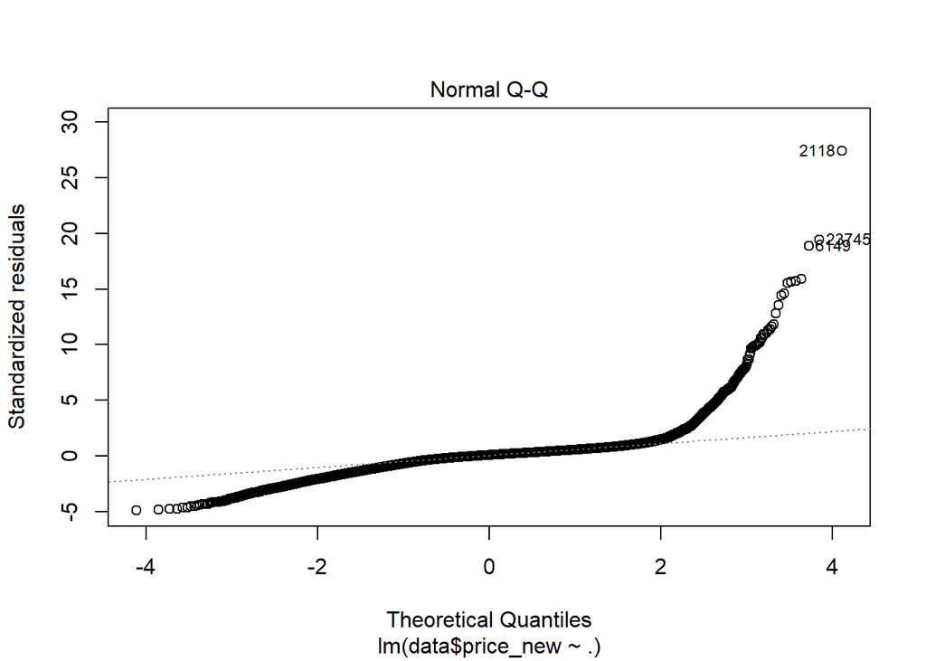

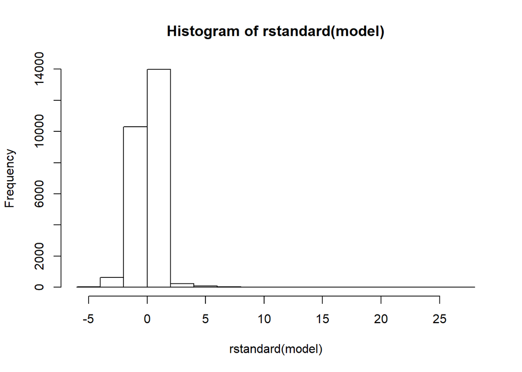

We run RESET test to check if our model is correctly specified that is our null hypothesis. Test results present misspisification because p-value is less than threshold, hence we have to reject null hypothesis.

```
##
##  RESET test
##
## data:  model
## RESET = 2157.2, df1 = 2, df2 = 25282, p-value < 2.2e-16
```

Possibly, it is outliers that cause problems with the specification.However according to Residuals versus Leverage plot none of otliers influence the model

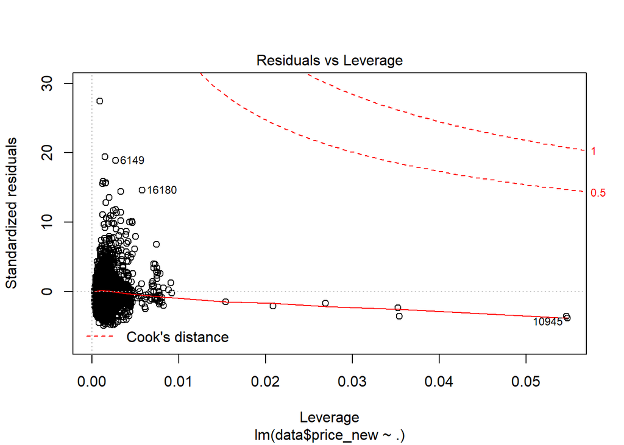

Plotting residuals versus predicted variable reveals a fair pattern that means the presence of heteroskedasticity.

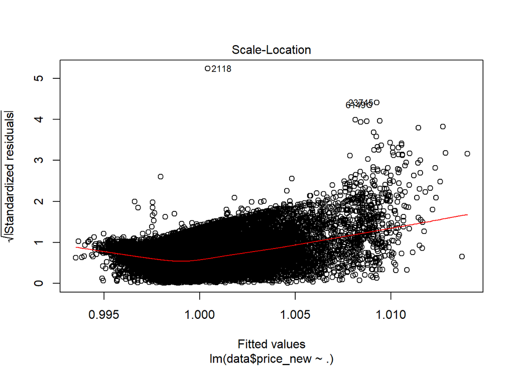

Bptest test helps to verify this output. Again, p-value is less than 0.05, so the presence of heteroskedasticity is confirmed.

```
##
##  studentized Breusch-Pagan test
##
## data:  model
## BP = 1422.5, df = 24, p-value < 2.2e-16
```

Summing up results of tests, we have three problems with model: - mispecification of model( non-linearity) - not normal distribution of residuals - heteroskedosticity

We can try non-linear transformations or transformation of outliers to solve problems

First we try to model logarithm of property price. However residuals plots show taking logarithm does not improve results

```
##
## Call:
## lm(formula = log(data$price_new) ~ ., data = data[, property_vars_new])
##
## Residuals:
##       Min        1Q    Median        3Q       Max
## -0.012862 -0.001161  0.000187  0.001077  0.072577
##
## Coefficients:
##                             Estimate Std. Error t value Pr(>|t|)
## (Intercept)               -6.639e-03  8.885e-05 -74.722  < 2e-16 ***
## full_sq                    1.251e-04  1.072e-06 116.710  < 2e-16 ***
## floor                      1.935e-05  3.614e-06   5.355 8.63e-08 ***
## state.L                    1.062e-03  9.848e-05  10.782  < 2e-16 ***
## state.Q                    1.243e-03  8.276e-05  15.021  < 2e-16 ***
## state.C                    6.029e-04  6.732e-05   8.955  < 2e-16 ***
## state^4                    9.573e-07  4.962e-05   0.019    0.985
## product_typeOwnerOccupier -3.537e-04  5.823e-05  -6.075 1.26e-09 ***
## is_material41              1.214e-03  9.814e-05  12.373  < 2e-16 ***
## part_kitchen               3.183e-03  2.609e-04  12.203  < 2e-16 ***
## ---
## Signif. codes:  0 '***' 0.001 '**' 0.01 '*' 0.05 '.' 0.1 ' ' 1
##
## Residual standard error: 0.002887 on 25299 degrees of freedom
## Multiple R-squared:  0.4111, Adjusted R-squared:  0.4109
## F-statistic:  1962 on 9 and 25299 DF,  p-value: < 2.2e-16
```

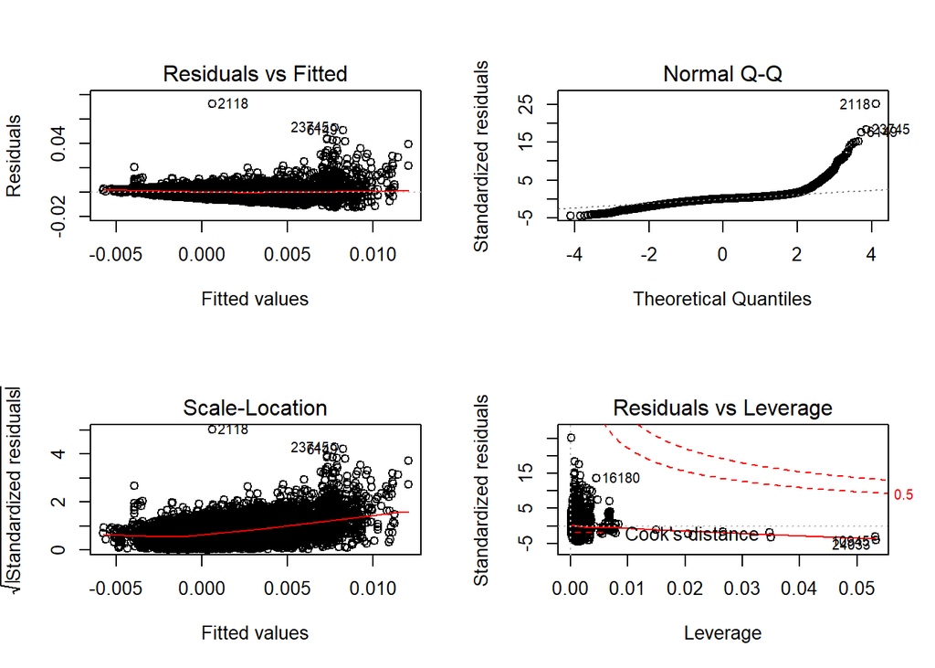

Next we can still try to decrese heteroskedosticity by removing influential outliers selected by following rool : cook distance>4/N, where N is number of rows in the dataset. In total, 5 percent of observations were named influential and were removed.

```
## [1] 0.05085148
```

It did significant progress. First, pattern in ploting residuals versus fitted values got less Second, removing outliers noticably increased r squares from 47% till 55%. The negative point is it changed the sign of sport_count_1000 variable, so we need again to deal with multicollinearity. Also standardized residuals still do not follow normal distribution.

```
##
## Call:
## lm(formula = data_no_inf$price_new ~ ., data = data_no_inf[,
##     ok_vars])
##
## Residuals:
##        Min         1Q     Median         3Q        Max
## -0.0078363 -0.0006867  0.0002144  0.0009585  0.0079221
##
## Coefficients:
##                               Estimate Std. Error  t value Pr(>|t|)
## (Intercept)                  9.933e-01  1.014e-04 9798.310  < 2e-16 ***
## full_sq                      1.075e-04  7.756e-07  138.603  < 2e-16 ***
## floor                        3.331e-05  2.349e-06   14.182  < 2e-16 ***
## state.L                      7.821e-04  7.663e-05   10.207  < 2e-16 ***
## state.Q                      1.002e-03  6.431e-05   15.587  < 2e-16 ***
## state.C                      5.001e-04  4.822e-05   10.371  < 2e-16 ***
## state^4                     -1.209e-04  3.260e-05   -3.708  0.00021 ***
## product_typeOwnerOccupier    2.878e-05  4.197e-05    0.686  0.49287
## sport_count_1000            -2.641e-05  5.897e-05   -0.448  0.65431
## cafe_avg_price_1500         -2.503e-06  3.063e-07   -8.172 3.17e-16 ***
## healthcare_centers_raion     4.827e-04  9.041e-05    5.339 9.45e-08 ***
## office_raion                 1.721e-08  3.296e-09    5.223 1.78e-07 ***
## cafe_sum_2000_max_price_avg  7.801e-08  1.332e-08    5.856 4.80e-09 ***
## cafe_sum_3000_min_price_avg  4.898e-05  9.280e-06    5.278 1.32e-07 ***
## cafe_sum_3000_max_price_avg -5.063e-05  3.467e-05   -1.460  0.14424
## cafe_sum_5000_min_price_avg  3.275e-06  2.956e-06    1.108  0.26784
## mkad_km                      4.711e-05  4.529e-06   10.403  < 2e-16 ***
## is_urban1                    8.965e-04  3.281e-05   27.323  < 2e-16 ***
## railroad_km                 -2.264e-05  8.446e-06   -2.681  0.00736 **
## public_transport_station_km -8.351e-04  9.430e-05   -8.856  < 2e-16 ***
## bus_terminal_avto_km        -2.987e-06  2.877e-06   -1.038  0.29924
## metro_km_walk               -7.547e-05  5.845e-06  -12.912  < 2e-16 ***
## green_part_1000              1.910e-06  1.094e-06    1.745  0.08091 .
## is_material41                1.016e-03  7.449e-05   13.637  < 2e-16 ***
## part_kitchen                 3.046e-03  2.241e-04   13.592  < 2e-16 ***
## ---
## Signif. codes:  0 '***' 0.001 '**' 0.01 '*' 0.05 '.' 0.1 ' ' 1
##
## Residual standard error: 0.001739 on 23997 degrees of freedom
## Multiple R-squared:  0.5446, Adjusted R-squared:  0.5442
## F-statistic:  1196 on 24 and 23997 DF,  p-value: < 2.2e-16
```

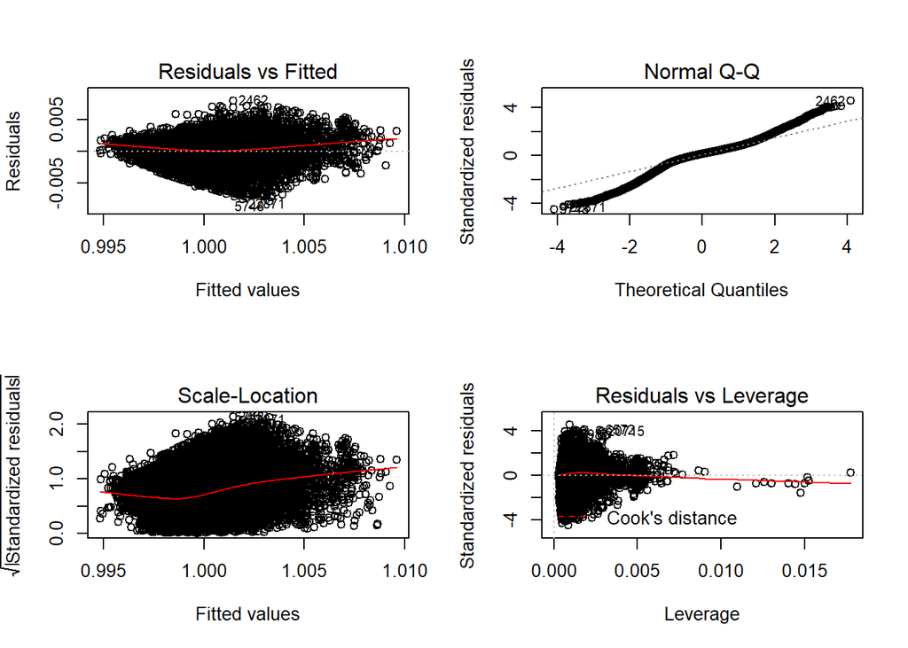

```
##  [1] "full_sq"                     "floor"
##  [3] "state"                       "price_new"
##  [5] "cafe_avg_price_1500"         "healthcare_centers_raion"
##  [7] "office_raion"                "cafe_sum_2000_max_price_avg"
##  [9] "cafe_sum_3000_min_price_avg" "mkad_km"
## [11] "is_urban"                    "railroad_km"
## [13] "public_transport_station_km" "metro_km_walk"
## [15] "green_part_1000"             "is_material4"
## [17] "part_kitchen"
```

```
##
## Call:
## lm(formula = data_no_inf$price_new ~ ., data = data_no_inf[,
##     ok_vars1])
##
## Residuals:
##        Min         1Q     Median         3Q        Max
## -0.0078330 -0.0006861  0.0002157  0.0009549  0.0079121
##
## Coefficients:
##                               Estimate Std. Error   t value Pr(>|t|)
## (Intercept)                  9.933e-01  8.089e-05 12278.763  < 2e-16 ***
## full_sq                      1.074e-04  7.727e-07   139.016  < 2e-16 ***
## floor                        3.340e-05  2.309e-06    14.468  < 2e-16 ***
## state.L                      7.772e-04  7.568e-05    10.270  < 2e-16 ***
## state.Q                      1.001e-03  6.424e-05    15.588  < 2e-16 ***
## state.C                      5.080e-04  4.657e-05    10.908  < 2e-16 ***
## state^4                     -1.251e-04  3.096e-05    -4.042 5.32e-05 ***
## cafe_avg_price_1500         -2.615e-06  2.878e-07    -9.085  < 2e-16 ***
## healthcare_centers_raion     5.223e-04  8.577e-05     6.089 1.15e-09 ***
## office_raion                 1.886e-08  2.833e-09     6.658 2.83e-11 ***
## cafe_sum_2000_max_price_avg  7.928e-08  1.294e-08     6.128 9.03e-10 ***
## cafe_sum_3000_min_price_avg  5.111e-05  8.941e-06     5.717 1.10e-08 ***
## mkad_km                      4.721e-05  3.769e-06    12.526  < 2e-16 ***
## is_urban1                    8.859e-04  3.025e-05    29.284  < 2e-16 ***
## railroad_km                 -2.292e-05  8.307e-06    -2.760  0.00579 **
## public_transport_station_km -8.348e-04  9.297e-05    -8.980  < 2e-16 ***
## metro_km_walk               -7.901e-05  4.015e-06   -19.680  < 2e-16 ***
## green_part_1000              1.930e-06  1.087e-06     1.775  0.07596 .
## is_material41                1.019e-03  7.436e-05    13.701  < 2e-16 ***
## part_kitchen                 2.989e-03  2.105e-04    14.196  < 2e-16 ***
## ---
## Signif. codes:  0 '***' 0.001 '**' 0.01 '*' 0.05 '.' 0.1 ' ' 1
##
## Residual standard error: 0.001739 on 24002 degrees of freedom
## Multiple R-squared:  0.5445, Adjusted R-squared:  0.5442
## F-statistic:  1510 on 19 and 24002 DF,  p-value: < 2.2e-16
```

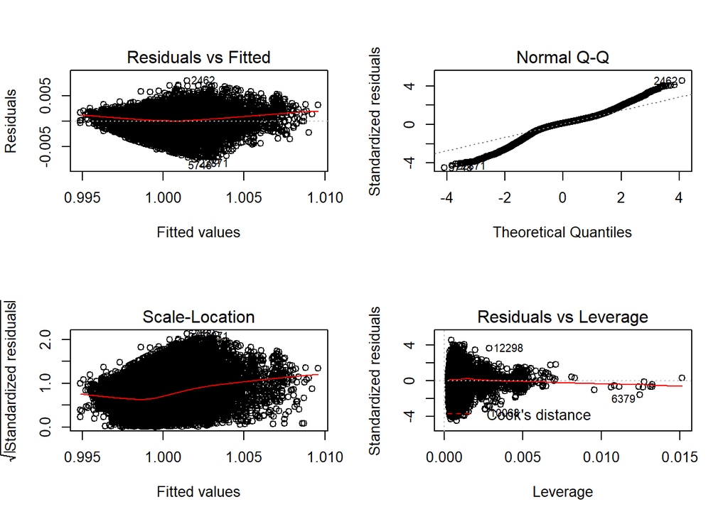

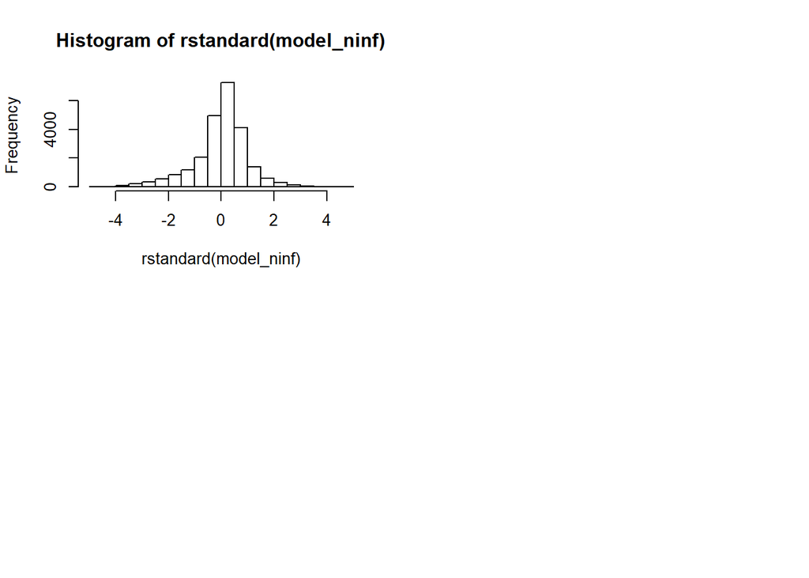

```
##
##  RESET test
##
## data:  model_ninf
## RESET = 409.23, df1 = 2, df2 = 24000, p-value < 2.2e-16
```

This paper has two outcomes:

First , relying on R-squared value we justified the importance of location associated factors, such as distance to public transport station or amount of offices in a distrinct in housing pricing in Moscow.

Second, we should conclude that prices in housing market are changing non-lineary with both internal and external factor, though price relationship with some of them like full area of property is very close to linear.